# Module 3 Report

M3 report group 21

SID:480435020, 480518622, 470376047, 480388575

University of Sydney | DATA2002 | 10/2019

# 1 Executive Summary

Based on the findings in *Meat Industry Strategic Plan*, the red meat industry’s key output is consumer products. The expectations of consumers and communities – in Australia and overseas – in relation to quality, integrity and production are on the rise. One key issue for the industry is the inability to increase the tenderness of the product. If this issue can be resolved, it will create more consistency for consumers and lead to product differentiation.

Actindin is an enzyme which is naturally found in the kiwifruit. It is known for improving tenderness in red meat, which can be used in the production of better products. The data set shows the statistical results of the impact of actinidin, derived from kiwifruit, on consumer sensory outcomes for tenderness. Meanwhile, we are also interested in other factors that may potentially affect consumer sensory outcomes such as the muscle the sample is from, aging period for the sample and cooking methods.

# 2 Full Report

## 2.1 Initial Data Analysis (IDA)

We first load the relevant packages and read in the CSV file on which we will perform our analysis.

```r
suppressMessages(library(tidyverse))
suppressMessages(library(janitor))
suppressMessages(library(readxl))
suppressMessages(library(magrittr))
suppressMessages(library(dplyr))
suppressMessages(library(knitr))
suppressMessages(library(kableExtra))
suppressMessages(library(ggfortify))
```

**Size of the data set**

```r
dim(data)
```

```
## [1] 1049  136
```

Each row represents statistics on a a muscle that was subject to a particular set of treatments.

Each column represents the relevant attributes related to each muscle such as unique sample identifier, unique animal identifiers and etc.

There are 1049 observations and 136 attributes/variables.

**Classification of Variables**

```r
glimpse(data)
```

[output not shown]

```r
options(knitr.table.format = "html")
```

- Tender represent for the average tenderness score of 10 customers, which is classified as numerical variable.
- Key 1 is unique animal identifiers, which has been classified as a categorical variable.
- Trail Notes indicates whether or not the sample was a **Control** sample or **Enhanced** with kiwifruit extract, which is a categorical variable.
- CUT tells us where the muscle sample from, such that **OUT005** for outside flat, **STR045** for striploin and **TDR062** for tenderloin. This is a categorical variable.
- D.AGED represents the aging period for the sample (10 or 28 days), which is categorical data. However, note that R has wrongly classified it as numerical data,
- COOK represent the way that sampled being cooked, where **GRL** is grill, **RST** is roast, **RST-C10** is roast, cold, 10mm slice and **RST-C2** is roast, cold, 2mm slice.This is categorical values.
- CarcWt is the weight of animals in kilograms, which is numerical data.

## 2.2 Data Cleaning

When importing the xlsx file, we have replaced all cells has “NA” with default NA. Since there are quite a few unnecessary columns only contains NA and we are not interested in them. So we decided to drop them to get a more brief data frame.

```r
df =remove_empty(data, which = c("cols"))

dim(df)
```

```
## [1] 1049   80
```

```r
colnames(df)
```

```
##  [1] "Sequence"     "Status"       "GROUP"        "MstGrp"
##  [5] "T/Test Ref"   "EQSRef"       "Carcase No."  "PrimalNo"
##  [9] "KEY 1"        "KEY 2"        "CUT"          "COOK"
## [13] "D.AGED"       "Position"     "SIDE"         "HANG"
## [17] "Kill Date"    "SEX"          "CarcWt"       "P8"
## [21] "Blue Index"   "Grader"       "HUMP"         "EMA"
## [25] "RiBFat"       "U-Oss"        "U-MB"         "A-MB"
## [29] "A-MC"         "A-FC"         "StunTime"     "STIM"
## [33] "StimTime"     "1-Time"       "1-pH"         "1-temp"
## [37] "2-Time"       "2-pH"         "2-temp"       "3-Time"
## [41] "3-pH"         "3-temp"       "4-Time"       "4-pH"
## [45] "4-temp"       "U-Time"       "pH-U"         "LTemp"
## [49] "Temp @ pH6"   "Comments"     "% Wagyu"      "Eartag"
## [53] "BREED"        "S-Breed"      "BrType"       "%BosInd"
## [57] "Est%BI"       "FEED"         "HGP YES/NO"   "FinalWt"
## [61] "EfinWt"       "Trial Notes"  "HGP Notes"    "LD_PF"
## [65] "LD_pH"        "LD_l"         "LD_a"         "LD_b"
## [69] "LD_LOSS"      "DNA Ref"      "System Use"   "Tender"
## [73] "Juicy"        "Flavour"      "O/all Like"   "MQ4"
## [77] "Satisfaction" "Country"      "City"         "Doneness"
```

Now, we only got 80 variables.

### 2.2.1 Checking for our variables of interest

**Missing Values**

```r
sum(is.na(df$`Trial Notes`)) #Kiwi extract
```

```
## [1] 0
```

```r
sum(is.na(df$cook)) #Cooking methods
```

```
## [1] 0
```

```r
sum(is.na(df$d_aged)) # Aging period
```

```
## [1] 0
```

```r
sum(is.na(df$cut)) # Cut/Muscle
```

```
## [1] 0
```

```r
sum(is.na(df$key_1)) # animal identifiers
```

```
## [1] 0
```

```r
sum(is.na(df$carc_wt)) # weight of animals
```

```
## [1] 0
```

```r
sum(is.na(df$tender)) # Tenderness score
```

```
## [1] 0
```

There are no missing value in these columns.

**Renaming rows and making into factors**

```r
df$kiwi = df$`Trial Notes`
cols = c("kiwi", "cut", "key_1", "d_aged", "cook")
df = df %>% janitor::clean_names() %>% mutate_each_(funs(factor(.)),cols)

df$d_aged <- as.factor(df$d_aged)
```

No further cleaning needed.

## 2.3 Demographics of the sample

**Tender**

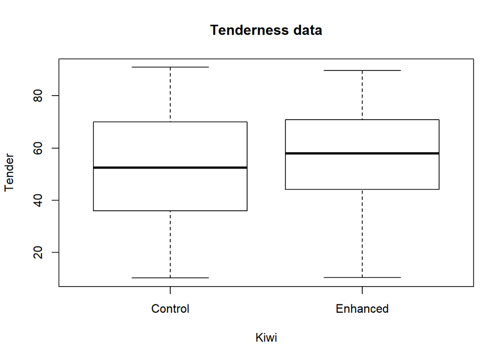

```r
# Plot the chart.
boxplot(tender ~ df$kiwi , data = df, xlab = "Kiwi",
   ylab = "Tender", main = "Tenderness data")
```

The bar graph indicates that the tenderness scores (ranging from 0-100) is approximately ranged in between scores of 10-90. With similar median around 52 for the control group and 57 for the enhanced group.

**Control or enhanced**

```r
library(kableExtra)
count (df,kiwi )%>%kable() %>% kable_styling(bootstrap_options = "hover")
```

| kiwi | n |
| --- | --- |
| Control | 581 |
| Enhanced | 468 |

Out of 1049 samples there were more control samples than the number of samples enhanced with kiwifruit extract. With 581 of the controlled sample and 468 enhanced by extract. Hence there’s a difference of113 samples. This is clearly presented in the visualisation through the bar chart below too.

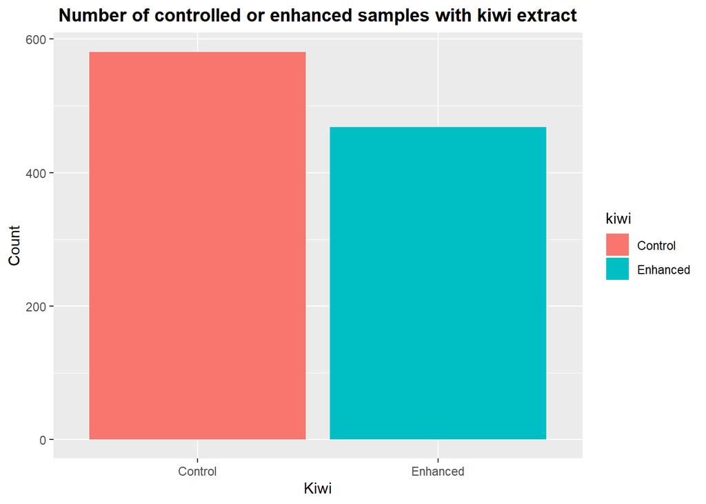

```r
df %>% ggplot() +aes(x = factor(kiwi), fill = kiwi) + geom_bar()+ labs(x='Kiwi', y='Count', title = 'Number of controlled or enhanced samples with kiwi extract') + theme(plot.title = element_text(hjust = 0.5, face = 'bold'))
```

**Different locations where the muscle sample is from**

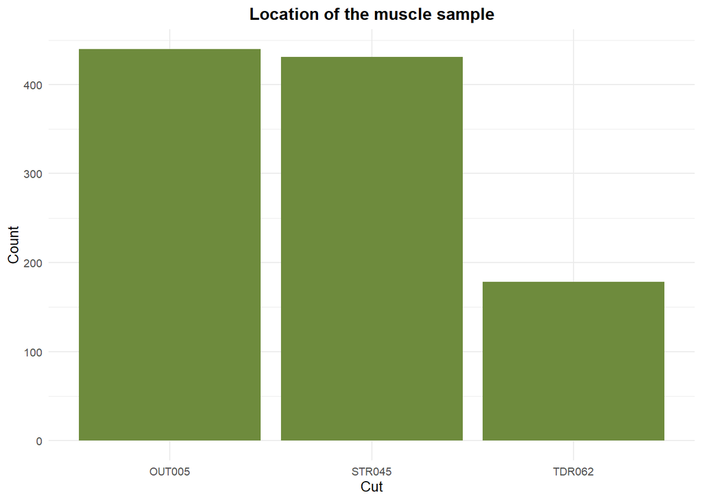

```r
df %>% ggplot() + aes(x = cut ) + geom_bar(fill = 'darkolivegreen4') +theme_minimal(base_size = 10) +
labs(x='Cut', y= 'Count', title = 'Location of the muscle sample') + theme(plot.title = element_text(hjust = 0.5, face = 'bold'))
```

From the bar graph above we can clearly identify that in this sample there’s a greater number of muscle from the outside flat (Out005), then followed by striploin (STR045) and the least sample muscles from tenderloin (TDR062).

```r
count(df,cut)%>%kable() %>% kable_styling(bootstrap_options = "hover")
```

| cut | n |
| --- | --- |
| OUT005 | 440 |
| STR045 | 431 |
| TDR062 | 178 |

From the summary table counts above, we can confirm that there’s 440 outside flat,431 striploin and 178 tenderloin.

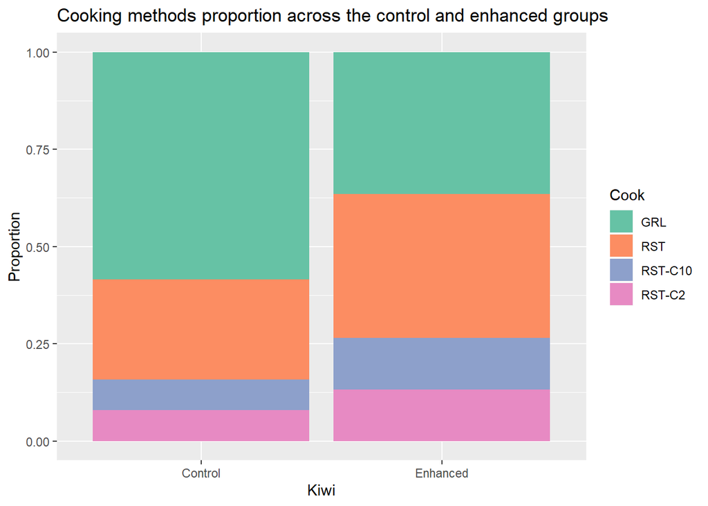

```r
df%>%
  ggplot() +
  aes(x = factor(kiwi), fill = cook) +
  labs(x = "Kiwi", y = "Proportion", title = "Cooking methods proportion across the control and enhanced groups", fill = "Cook") +
  scale_fill_brewer(palette = "Set2") +
  geom_bar(position = "fill")
```

**Aging period**

```r
df %>%
  select(d_aged) %>%
  count(d_aged) %>%
  arrange(desc(n)) %>%
  rename(Agingperiod = d_aged, Count = n) %>%
  kable() %>%
  kable_styling(bootstrap_options = c("hover", "condensed"), full_width = TRUE)
```

| Agingperiod | Count |
| --- | --- |
| 10 | 575 |
| 28 | 474 |

There are 2 aging period from the samples 10 or 28 days. 575 of the samples are aged 10 days and 474 aged 28 days.

## 2.4 Research Questions

To examine an overall inquiry into whether the kiwifruit extract treatment has a statistically significant improvement on tenderness, we must first consider if the extract has a significant effect independently. Then, we account for other possible variables that were also introduced in the cooking process, including factors like aging periods, cuts/muscles as well as differing cooking methods.

Then, we could look at whether there are differences in between cooking methods, aging periods and muscles that affect tenderness respectively.

Finally, it is also important to evaluate the size of these statistical differences by considering if tenderness plays an active role in informing the overall satisfaction of consumers, thus confirming whether the kiwifruit extract has a notable and meaningful positive difference detectable by consumers.

### 2.4.1 Does the kiwifruit extract treatment improve tenderness?

In considering the effects of kiwifruit extract treatment on tenderness, we must first examine the data and consider whether it satisfies underlying assumptions of ANOVA, including independence, normality and equal variance for each of its groups.

Firstly, we can confirm that the sample is independent and identically distributed as the knowing about sample X (meat with kiwi extract treatment) cannot give you information about sample Y (meat without kiwi treatment), thus satisfying independence. Both subsets also follows a consistent distribution as seen in the visualisation below.

We first utilise a box plot and qqplots to visualise the data.

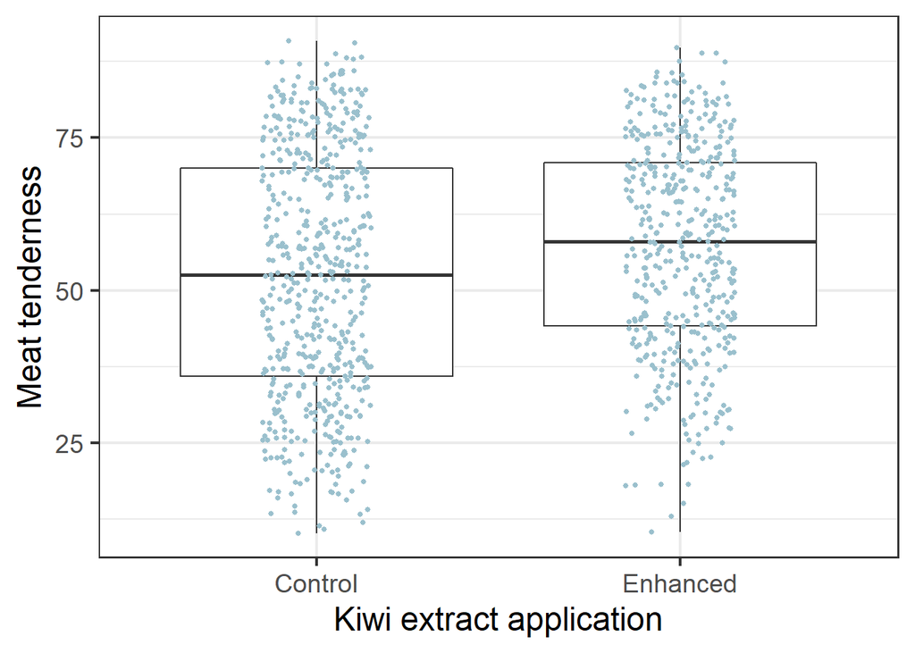

```r
ggplot(df, aes(x = kiwi, y = tender)) +
  geom_boxplot() +
  geom_jitter(width=0.15, size = 1, colour = "lightblue3") +
  theme_bw(base_size = 18) +
  labs(x = "Kiwi extract application", y = "Meat tenderness")
```

```r
summary = df %>% group_by(kiwi) %>% summarise(
    n = n(),
    mean = mean(tender),
    variance = var(tender))

kable(summary, format = "html", digits = 3) %>%
  kable_styling(bootstrap_options = c("hover", "condensed"), full_width = TRUE)
```

| kiwi | n | mean | variance |
| --- | --- | --- | --- |
| Control | 581 | 52.361 | 410.510 |
| Enhanced | 468 | 57.085 | 289.785 |

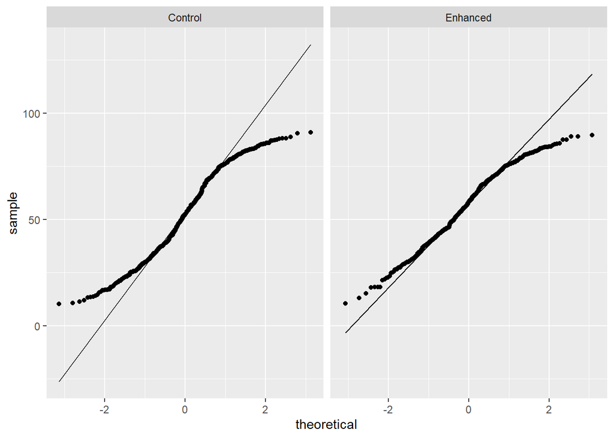

```r
ggplot(df, aes(sample = tender, colour = tender)) + geom_qq() + geom_qq_line() + facet_wrap(~kiwi)
```

Whilst in the box plot the variance appears similar, statistical analysis shows a discrepancy of ~100 (410.5 for control and 289.8 for enhanced) that could potentially undermine the validity of our hypothesis tests using ANOVA. The QQplots for the Control/Enhanced samples also deviated from a normal distribution at both extremities somewhat substantially.

Thus, more specific analysis of the residuals were taken utilising autoplot to generate both a residuals vs fitted graph and a normal QQplot that included standardised residuals. This allowed us to account for the influence of other treatment factors, including cooking methods, aging periods and cuts/muscles as well as blocks including differing cows and their carcass weight.

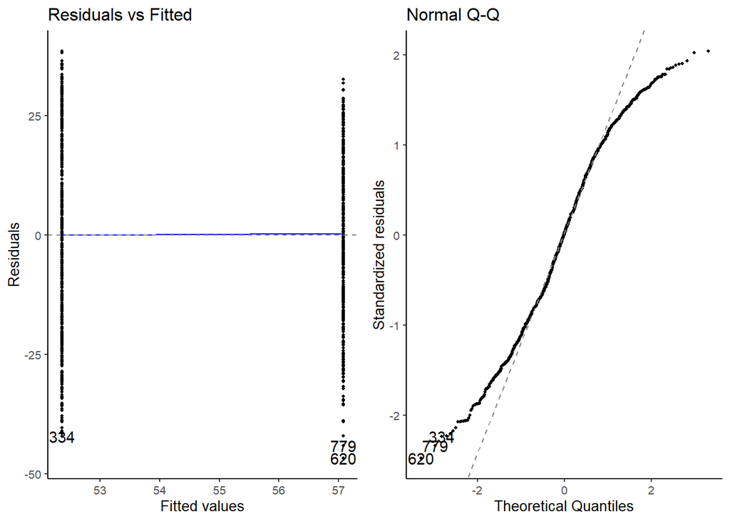

```r
fit1 = aov(tender ~ kiwi, data = df)
autoplot(fit1, which = 1:2, size = 0.8,
         ad.size = 0.5, colour = "black") +
  theme_classic(base_size = 10)
```

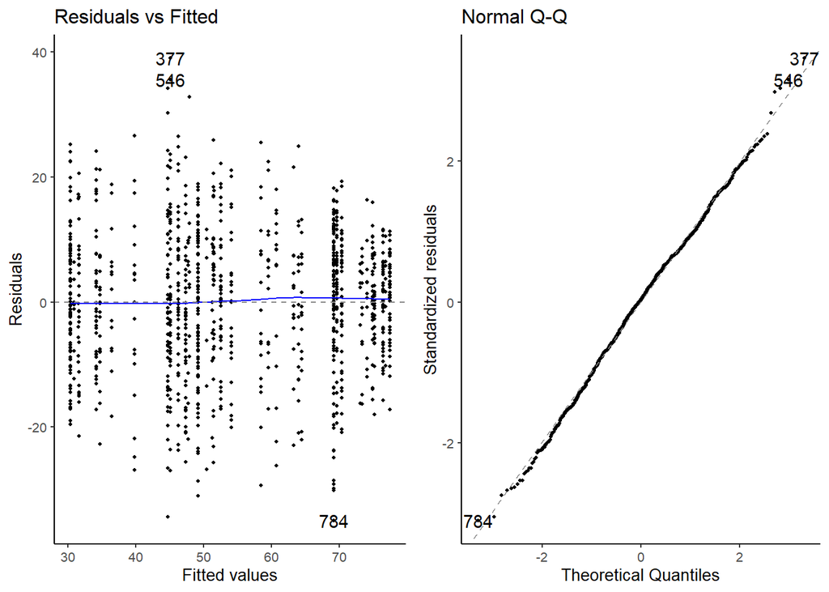

```r
fit2 = aov(tender ~ kiwi*cook + kiwi*d_aged + kiwi*cut + cook*d_aged + cook*cut + d_aged*cut, data = df)
autoplot(fit2, which = 1:2, size = 0.8,
         ad.size = 0.5, colour = "black") +
  theme_classic(base_size = 10)
```

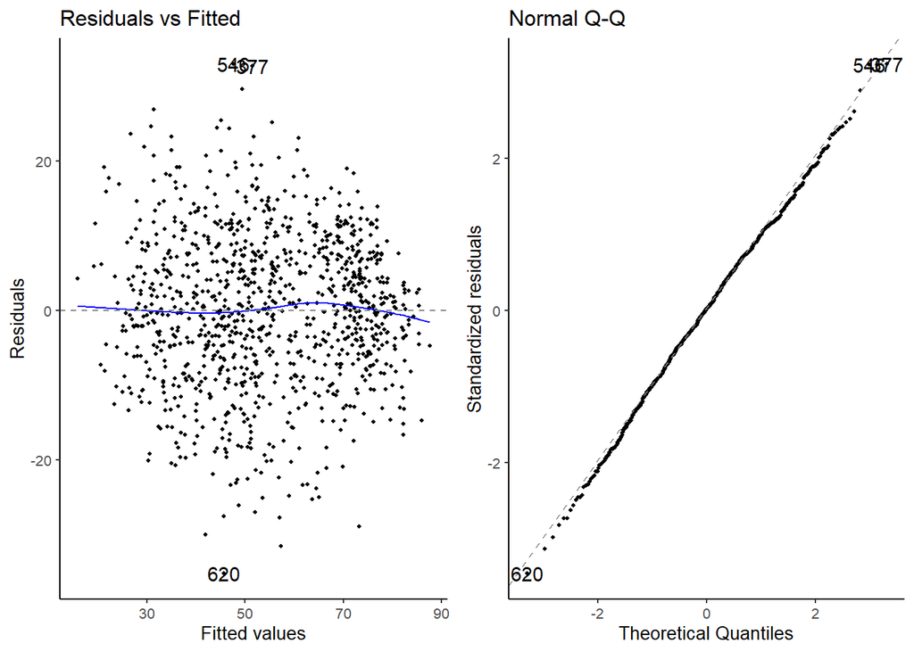

```r
fit3 = aov(tender ~ kiwi*cook + kiwi*d_aged + kiwi*cut + cook*d_aged + cook*cut + d_aged*cut + carcase_no + key_1, data = df)
autoplot(fit3, which = 1:2, size = 0.8,
         ad.size = 0.5, colour = "black") +
  theme_classic(base_size = 10)
```

To that effect, 3 models were developed with the first only included the kiwi extract. The second and third adjustment accounted for both treatment factors and blocks respectively, and correspondingly we can see from the data visualisation: a) that the spread of residuals within the residuals plot becomes more even/random below and above the central line across a range of fitted values, indicating equal variance b) the residual is more closely aligned with the normal as points are getting reasonably closer to the diagonal line in our QQplot.

Considering a data transformation by log, inverse or square root did not improve variance and provided worse results in normality (the square root transformation residual plots were used as an example).

Thus we can proceed with our ANOVA analysis without transformation if we include and account for both relevant treatment and blocking factors to satisfy our assumptions.

```r
#transformation
df_trans = df %>% mutate(inv_tender = 1/tender, log_tender = log(tender), sqrt_tender = sqrt(tender))

df_trans %>% group_by(kiwi) %>% summarise(
    n = n(),
    mean = mean(tender),
    variance1 = var(tender),
    var2 = var(inv_tender),
    var3 = var(log_tender),
    var4 = var(sqrt_tender),
  )
```

```
## # A tibble: 2 x 7
##   kiwi         n  mean variance1      var2  var3  var4
##   <fct>    <int> <dbl>     <dbl>     <dbl> <dbl> <dbl>
## 1 Control    581  52.4      411. 0.000165  0.203  2.17
## 2 Enhanced   468  57.1      290. 0.0000803 0.122  1.42
```

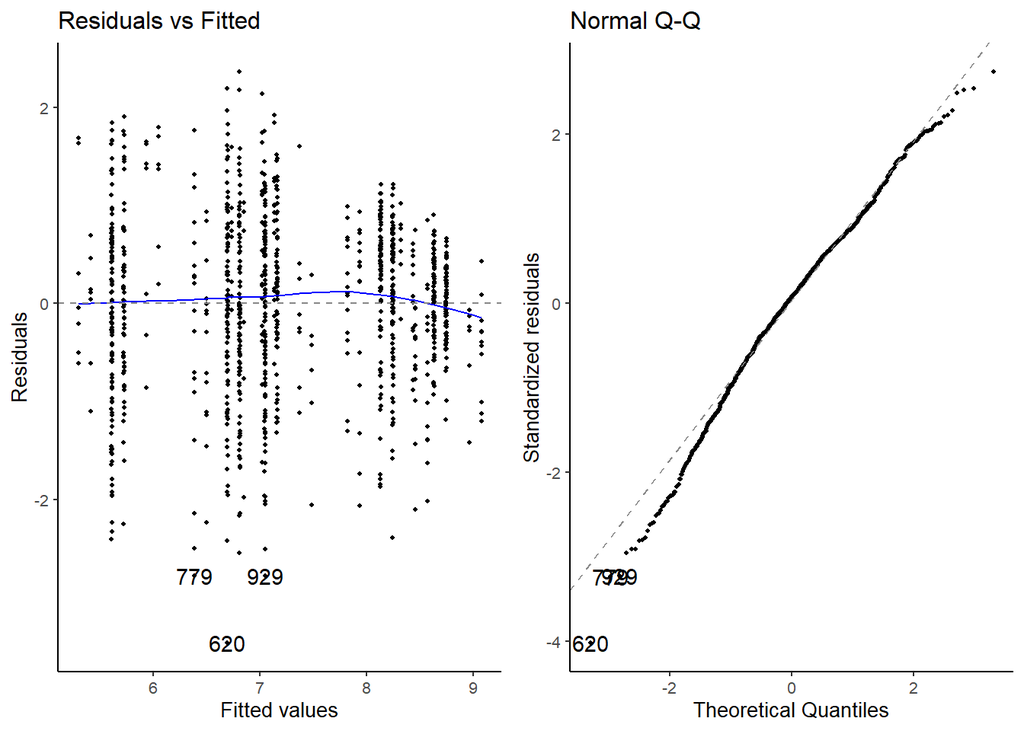

```r
trans_fit = aov(sqrt_tender ~ cut + cook + d_aged + kiwi, data = df_trans)
autoplot(trans_fit, which = 1:2, size = 0.8,
         ad.size = 0.5, colour = "black") +
  theme_classic(base_size = 10)
```

```r
#doesn't improve variance and worse in normality.
#we can assume similar variance and normality
```

#### 2.4.1.1 Part A: 2 sample t-test

Firstly, we run a 2 sample t-test to test as a preliminary for whether the application of kiwi extract treatment has a statistically significant enhancement on the tenderness of meat.

**Hypothesis:**

Let $μ_X$ and $μ_Y$ be the population mean for tenderness of meat treated with the kiwi extract (Enhanced) and those not treated with the kiwi extract (Control) respectively.

$H_0: μ_X = μ_Y$

$H_1: μ_X \geqslant μ_Y$

**Assumptions:**

$X_1,…,X_n$ and $Y_1,…,Y_n$ (the data) is independent and identically distributed.

The groups (Enhanced $X_i$ and Control $Y_i$) are independent from one another.

Both groups have equal variance and is normally distributed: $N(μ_X, σ^2)$ and $N(μ_Y, σ^2)$.

The assumptions have been considered and satisfied above, as the assumptions for a 2-sample t-test is identical to ANOVA.

**Test statistic:**

$T=\frac{\bar{X} −\bar{Y}}{S_p \sqrt{\frac{1}{n1} +\frac{1}{n2}}}$ where $S_p^2 = \frac{(n_x-1)S_x^2 + (n_y-1)S_x^2}{n_x+n_y-2}$. Under $H_0, T~t n_x+n_y-2$

```r
#Performing statistical test
##Manual 2 sample t-test

enhanced = filter(df, kiwi == "Enhanced")$tender
control = filter(df, kiwi == "Control")$tender

nS = length(enhanced)
nN = length(control)
sS = sd(enhanced)
sN = sd(control)
sP = sqrt(((nS - 1) * sS^2 + (nN - 1) * sN^2)/
            (nS + nN - 2))

xbarS = mean(enhanced)
xbarN = mean(control)
deg_free = nS+nN-2

t0 = (xbarS - xbarN) / ( sP * sqrt(1/nS+1/nN) )
p_val = (1-pt(abs(t0),deg_free))
c(round(t0,5), round(p_val, 5))
```

```
## [1] 4.02700 0.00003
```

**Observed test statistic:**

Thus, the observed test statistic is 4.027, and the degrees of freedom is $468+581-2 = 1047$

**P-value**

We can confirm the result with the R in-built 2 sample t-test.

```r
## 2 sample t-test (assuming variance equal)
t.test(enhanced, control, alternative = 'greater', var.equal = TRUE)
```

```
##
##  Two Sample t-test
##
## data:  enhanced and control
## t = 4.027, df = 1047, p-value = 3.029e-05
## alternative hypothesis: true difference in means is greater than 0
## 95 percent confidence interval:
##  2.792594      Inf
## sample estimates:
## mean of x mean of y
##  57.08514  52.36139
```

**Conclusion:**

As the p-value, p ≈ 0.00003 < 0.05 (with level of significance at 5%) is consistent with manual calculations, there is sufficient evidence to reject $H_0$ at the 5% level of significance. Thus we conclude that there is strong evidence to suggest that there’s a statistically significant enhancement/increase in tenderness for meat with applied the kiwi extract compared to meat which did not.

Visualising the data accords with our conclusion as well as there does appear to be discernible differences between the Enhanced and Control Groups in regards to tenderness.

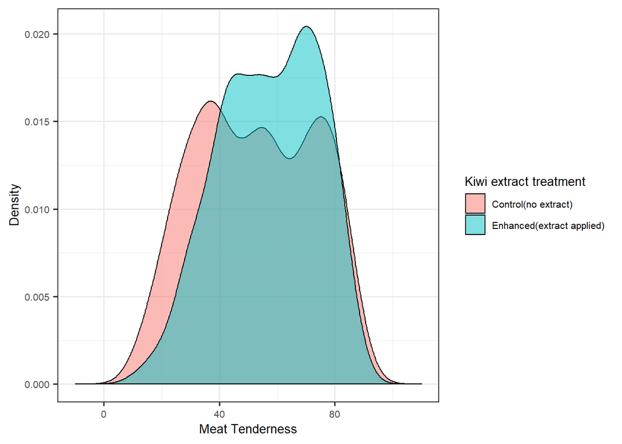

```r
living = ggplot(df,aes(x = tender, fill = kiwi))+
  geom_density(alpha = 0.5) +
  theme_bw(base_size = 14) +
  xlim(-10, 110) +
  labs(x="Meat Tenderness", y = "Density") +
  guides(fill=guide_legend(title = "Kiwi extract treatment")) +
  scale_fill_discrete(labels = c("Control(no extract)", "Enhanced(extract applied)")) +
  theme(text = element_text(size=10))
living
```

However, this does not account for the influence of many other treatment factors and their interaction with the kiwi extract (as well as blocks) in influencing tenderness. This can potentially invalidate our conclusion if we do not account for them. In building a sufficient ANOVA model that accommodates for all relevant interactions, factors and blocks, we must include them all and then omit those that are irrelevant so that degrees of freedom/residuals are not taken up unnecessarily and hence reduce the power of our hypothesis tests.

#### 2.4.1.2 Part B: two-factor ANOVA test for interaction

To that effect, we now consider whether there is an interaction between kiwi extract and other treatment factors (including Dry Age, Cut, Cook) through a series of two-factor ANOVA test for interaction.

An appropriate model formula for a two-way ANOVA is as follows:

$Y_{ijk}=μ+α_i+γ_j+(αγ)_{ij}+ε_{ijk}$

Where μ is the overall mean, $α_i$ and $γ_j$ are treatment effects (differences between treatment group means and the overall mean),$(αγ)_{ij}$ are the interaction effects and $ε_{ijk}∼N(0,σ2)$. We also require the following constraints:

$∑_iα_i=0$ $∑_jγ_j=0$ For each j, $∑_i(αγ)_{ij}=0$ For each i, $∑_i(αγ)_{ij}=0$

Thus for our example, we are going to analyse the interaction effects of kiwi extract and differing cooking methods. This will form a generalized procedure for our remaining interaction test, as the procedures applied are almost identical (with the exception that the i and j, the number of categories within each variable could potentially change).

**Hypothesis:**

$H_0: (αγ)_{ij}=0$ for all $i=1,2$ and $j=1,2,3,4$ $H_1:$ not all $(αγ)_{ij}=0$

**Assumptions:**

ANOVA assumes the residuals follow a normal distribution with constant variance. We have checked this above using a scatter plot of the residuals against the fitted values for homoskedasticity in constant error variance over the range of fitted values and a normal quantile plot as discussed above.

**Test statistic:**

```r
#optional (tabulates data)
df %>% group_by(kiwi, cook) %>% summarise(
  xbar = mean(tender),
  n = n())
```

```
## # A tibble: 8 x 4
## # Groups:   kiwi [2]
##   kiwi     cook     xbar     n
##   <fct>    <fct>   <dbl> <int>
## 1 Control  GRL      50.2   340
## 2 Control  RST      54.7   149
## 3 Control  RST-C10  54.3    46
## 4 Control  RST-C2   59.0    46
## 5 Enhanced GRL      58.2   171
## 6 Enhanced RST      57.0   173
## 7 Enhanced RST-C10  50.1    62
## 8 Enhanced RST-C2   61.2    62
```

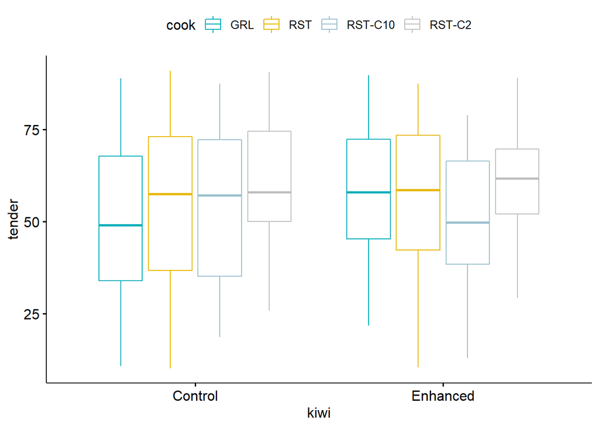

```r
library("ggpubr")
ggboxplot(df, x = "kiwi", y = "tender", color = "cook",
          palette = c("#00AFBB", "#E7B800", "lightblue3", "gray"))
```

```r
a1 = aov(tender ~ kiwi * cook, data = df)
summary(a1)
```

```
##               Df Sum Sq Mean Sq F value   Pr(>F)
## kiwi           1   5784    5784  16.516 5.19e-05 ***
## cook           3   4975    1658   4.735  0.00275 **
## kiwi:cook      3   3889    1296   3.701  0.01146 *
## Residuals   1041 364562     350
## ---
## Signif. codes:  0 '***' 0.001 '**' 0.01 '*' 0.05 '.' 0.1 ' ' 1
```

The Test statistic = Mean Sq Interaction/Mean Sq Residual = 1296/350 = $3.701$

It also follows an F distribution with $(a-1)(b-1) = (4−1)(2−1) = 3$ and $ab(n-1) = 1041$ degrees of freedom under $H_0$.

**Observed test statistic:**

As we can see from the graph, the observed test statistic, $t_0 = 3.701$

**P-value:**

$P(F_{3,1041}≥ t_0)=P(F_{3,1041}≥3.701)= 0.011$

**Conclusion:**

As the p-value, p ≈ 0.011 < 0.05 (with level of significance at 5%), there is sufficient evidence against $H_0$ at the 5% level of significance to suggest that the interaction effects are not zero. Thus we should retain the interaction term in the model.

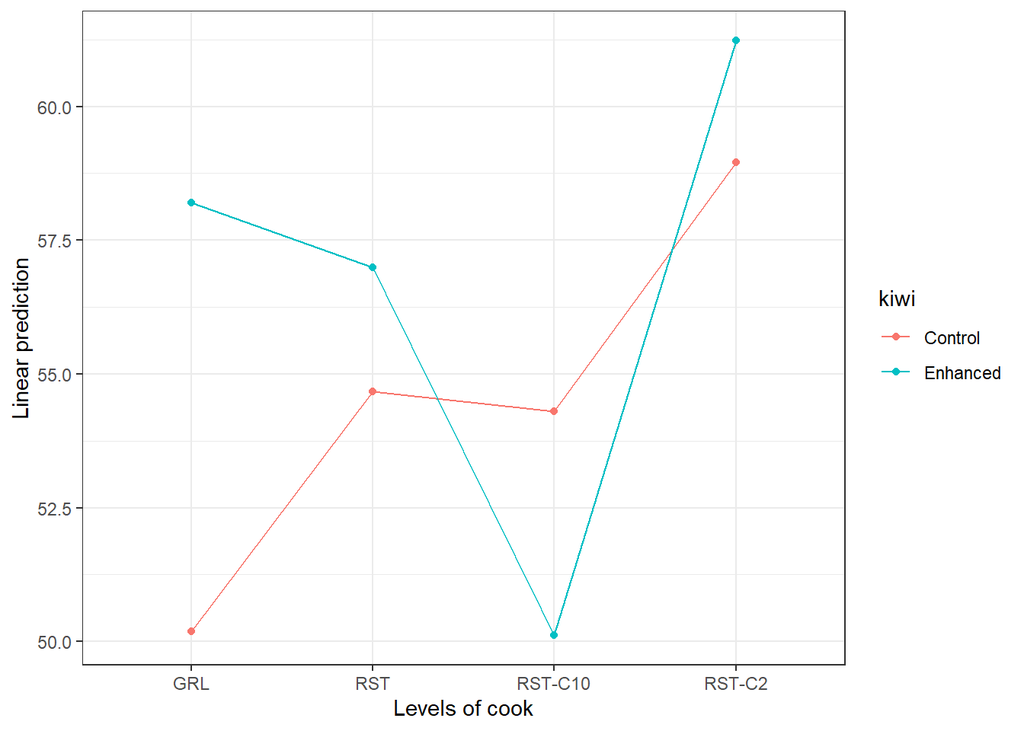

```r
library(emmeans)
emmip(a1, kiwi ~ cook) + theme_bw()
```

By generating an interaction plot, we can see numerous intersections that suggest there are interactions between differing cooking methods and the application of kiwi extract in affecting meat tenderness. This also accords with our conclusion above.

Applying a similar approach to the interaction effects of: - kiwi extract and aging period - kiwi extract and cut/muscle - aging period and cooking method - aging period and cut/muscle - cooking method and cut/muscle

```r
a2 = aov(tender ~ kiwi * d_aged , data = df)
summary(a2)
```

```
##               Df Sum Sq Mean Sq F value   Pr(>F)
## kiwi           1   5784    5784  16.461 5.34e-05 ***
## d_aged         1   3846    3846  10.944 0.000971 ***
## kiwi:d_aged    1   2392    2392   6.807 0.009211 **
## Residuals   1045 367188     351
## ---
## Signif. codes:  0 '***' 0.001 '**' 0.01 '*' 0.05 '.' 0.1 ' ' 1
```

```r
a3 = aov(tender ~ kiwi * cut , data = df)
summary(a3)
```

```
##               Df Sum Sq Mean Sq F value   Pr(>F)
## kiwi           1   5784    5784  40.975 2.33e-10 ***
## cut            2 225338  112669 798.181  < 2e-16 ***
## kiwi:cut       1    720     720   5.098   0.0242 *
## Residuals   1044 147368     141
## ---
## Signif. codes:  0 '***' 0.001 '**' 0.01 '*' 0.05 '.' 0.1 ' ' 1
```

```r
a4 = aov(tender ~ d_aged * cook, data = df)
summary(a4)
```

```
##               Df Sum Sq Mean Sq F value   Pr(>F)
## d_aged         1   4527    4527  12.857 0.000352 ***
## cook           3   5797    1932   5.488 0.000964 ***
## d_aged:cook    3   2334     778   2.210 0.085369 .
## Residuals   1041 366551     352
## ---
## Signif. codes:  0 '***' 0.001 '**' 0.01 '*' 0.05 '.' 0.1 ' ' 1
```

```r
a5 = aov(tender ~ d_aged * cut, data = df)
summary(a5)
```

```
##               Df Sum Sq Mean Sq F value   Pr(>F)
## d_aged         1   4527    4527  24.098 1.06e-06 ***
## cut            2 178363   89181 474.711  < 2e-16 ***
## d_aged:cut     2    377     189   1.004    0.367
## Residuals   1043 195943     188
## ---
## Signif. codes:  0 '***' 0.001 '**' 0.01 '*' 0.05 '.' 0.1 ' ' 1
```

```r
a6 = aov(tender ~ cook * cut, data = df)
summary(a6)
```

```
##               Df Sum Sq Mean Sq F value   Pr(>F)
## cook           3   6320    2107  11.990 1.01e-07 ***
## cut            2 181003   90502 515.108  < 2e-16 ***
## cook:cut       6   9691    1615   9.193 7.94e-10 ***
## Residuals   1037 182196     176
## ---
## Signif. codes:  0 '***' 0.001 '**' 0.01 '*' 0.05 '.' 0.1 ' ' 1
```

From the ANOVA tests above, we can see that the interaction between aging period and cut/muscle, as well as aging period and cooking method have no statistically significant interaction.

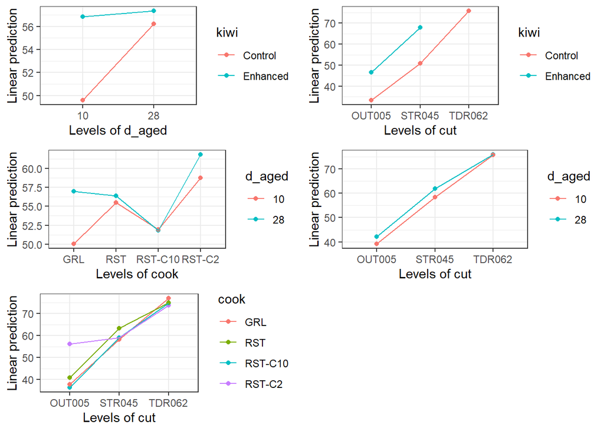

```r
i1= emmip(a2, kiwi ~ d_aged) + theme_bw()
i2= emmip(a3, kiwi ~ cut) + theme_bw()
i3= emmip(a4, d_aged ~ cook) + theme_bw()
i4= emmip(a5, d_aged ~ cut) + theme_bw()
i5= emmip(a6, cook ~ cut) + theme_bw()

gridExtra::grid.arrange(i1, i2, i3, i4, i5, ncol = 2)
```

Thus, we will drop these interaction terms from the model.

#### 2.4.1.3 PART C: 2-way ANOVA with additional factors & blocks

Having found that the interaction term is not significant, we can proceed to consider whether or not there are any differences between the means of the main effects. Namely, we can now affirm our initial conclusion of Kiwi Extract significantly enhancing tenderness (as a result of our 2 sample t-test) with an corresponding ANOVA test that accounts for the presence and interaction of relevant factors within our sampled data. This new model will also account for blocks.

The relevant formula for this 2-way ANOVA test includes:

$Y_{ijk}=μ+α_i+γ_j+b_k+c_l+(αγ)_{ij}+(αb)_{ik}+ (αc)_{il}+(bc)_{kl}+d_m+e_n+ε_{ijk}$

Where μ is the overall mean, $α_i, γ_j, b_k, c_l$ the treatment effects (differences between treatment group means and the overall mean) of kiwi, aging, cook and cut respectively, with $(αγ)_{ij}, (αb)_{ik}, (αc)_{il}, (bc)_{kl}$ as the relevant interaction effects (non-significant ones excluded). Additionally, $d_m, e_n$ are the blocking variables -carcass weight and the unique identifier for a cow respectively. Finally, the residual is represented as $ε_{ijk}∼N(0,σ2)$. We also require the following constraints:

$∑_iα_i=0$ $∑_jγ_j=0$ $∑_kb_k=0$ $∑_lc_l=0$ $∑_md_l=0$ $∑_ne_l=0$

For each j, $∑_i(αγ)_{ij}=0$ For each i, $∑_i(αγ)_{ij}=0$ For each i, $∑_i(αb)_{ik}=0$ For each k, $∑_i(αb)_{ik}=0$

(…and so on for each remaining interaction effect)

Let α1 and α2 be the treatment effects for the two levels of the Kiwi Extract variable (Enhanced and Control, respectively).

**Hypothesis:**

$H0: α1=α2=0$

$H1:$ not all $α_i$ equal to 0

**Assumptions:**

ANOVA assumes the residuals follow a normal distribution with constant variance. We have checked this above using a scatter plot of the residuals against the fitted values for homoskedasticity (constant error variance over the range of fitted values) and a normal quantile plot for normality as discussed above.

```r
final= aov(tender ~ kiwi*cook + kiwi*d_aged + kiwi*cut + cook*cut + carcase_no + key_1, data = df)
summary(final)
```

```
##              Df Sum Sq Mean Sq F value   Pr(>F)
## kiwi          1   5784    5784  50.319 2.56e-12 ***
## cook          3   4975    1658  14.427 3.40e-09 ***
## d_aged        1   3568    3568  31.041 3.30e-08 ***
## cut           2 221053  110526 961.560  < 2e-16 ***
## carcase_no    1    324     324   2.821  0.09338 .
## key_1        85  23416     275   2.397 2.70e-10 ***
## kiwi:cook     3   1093     364   3.168  0.02373 *
## kiwi:d_aged   1    922     922   8.020  0.00473 **
## kiwi:cut      1    758     758   6.591  0.01040 *
## cook:cut      6   8810    1468  12.775 6.62e-14 ***
## Residuals   944 108508     115
## ---
## Signif. codes:  0 '***' 0.001 '**' 0.01 '*' 0.05 '.' 0.1 ' ' 1
```

**Test statistic**

The Test statistic = Mean Sq Interaction/Mean Sq Residual

It also follows a F distribution with $a−1$ and $ab(n−1)$ degrees of freedom under $H_0$.

**Observed test statistic:**

As we can see from the ANOVA summary table (or roughly similar manually $5784/115 = 50.296$), the observed test statistic is $t_0 = 50.319$.

**P-value:**

$P(F_{1,944}≥ t_0)=P(F_{1,944}≥50.319) < 0.00001$

**Conclusion:**

As the p-value, p < 0.00001 is significantly less than 0.05 (with level of significance at 5%), there is overwhelming evidence against $H_0$ at the 5% level of significance to suggest a statistically significant enhancement/increase in tenderness for meat which applied the kiwi extract compared to meat which did not.

### 2.4.2 Other general Questions

Following the primal question, we are interested to test whether there’s significant differences in tenderness of meat with the existence of other factors.

**Do other factors, namely cooking methods, aging periods and muscles/cut affect tenderness?**

#### 2.4.2.1 Are tenderness different between cooking methods?

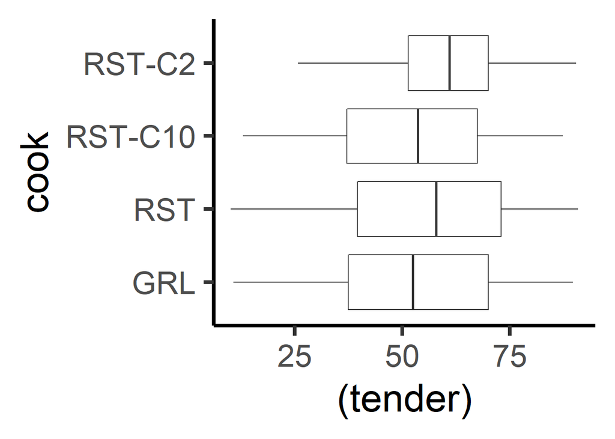

```r
df %>% ggplot(aes(x = cook , y = (tender), fill = tender)) +
  geom_boxplot() + coord_flip() +
  theme_classic(base_size = 32)
```

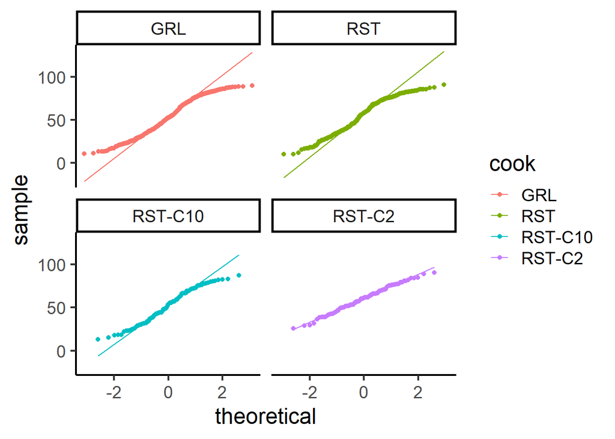

```r
df %>% ggplot(aes(sample = tender, colour = cook)) +
  geom_qq() + geom_qq_line() +
  facet_wrap(~cook) +
  theme_classic(base_size = 18)
```

As per above, we through the visualisation of the qq-plots mostly fits well and in align with the lines, hence the normality assumption of the ANOVA test is likely satisfied. Moreover, the 4 groups of cooking methods has approximately similar variances as indicated by the boxplots with similar mean and distributions. Only RCT-C2 (roast, cold, 2mm slice) has a comparably smaller variance. Hence, as all assumptions are likely satisfied we continue with the tests.

This 2-way ANOVA test includes the consideration of the significant interaction effects and effective blocks:

$Y_{ijk}=μ+α_i+(αγ)_{ij}+(αb)_{ik}+d_m+e_n+ε_{ijk}$

$∑_iα_i=0$ $∑_md_l=0$ $∑_ne_l=0$ For each j, $∑_i(αγ)_{ij}=0$ For each i, $∑_i(αγ)_{ij}=0$ For each i, $∑_i(αb)_{ik}=0$ For each k, $∑_i(αb)_{ik}=0$

Let α_1, α_2, α_3, α_4 be the treatment effects for the 4 different cooking methods of the meat, which takes values GRL (grill), RST (roast), RST-C10 (roast, cold, 10mm slice), RST-C2 (roast, cold, 2mm slice).

**Hypothesis:**

$H0: α_1=α_2=α_3=α_4=0$

$H1:$ not all $α_i$ equal to 0

**Assumptions:**

ANOVA assumes the residuals follow a normal distribution with constant variance. We have checked this above using a qqplot and box plot as discussed above.

**Test statistic**

The Test statistic = Mean Sq Interaction/Mean Sq Residual

It also follows a F distribution with $a−1$ and $ab(n−1)$ degrees of freedom under $H_0$.

```r
summary(aov(tender ~ cook + kiwi:cook +  cook:cut + carcase_no + key_1, data = df))
```

```
##              Df Sum Sq Mean Sq F value   Pr(>F)
## cook          3   6320    2107  17.989 2.33e-11 ***
## carcase_no    1    761     761   6.501   0.0109 *
## key_1        85  27922     328   2.805 3.75e-14 ***
## cook:kiwi     4   8911    2228  19.023 4.63e-15 ***
## cook:cut      8 224401   28050 239.537  < 2e-16 ***
## Residuals   947 110895     117
## ---
## Signif. codes:  0 '***' 0.001 '**' 0.01 '*' 0.05 '.' 0.1 ' ' 1
```

**Observed test statistic:**

The observed test statistic is $t_0 = 17.989$.

**P-value:**

**Conclusion:**

As the p-value, p < 0.00001 is significantly less than 0.05 (with level of significance at 5%), there is evidence against $H_0$ at the 5% level of significance to suggest a statistically significant differences between the tenderness affected by the 4 different cooking methods of the meat.

#### 2.4.2.2 Relationships between tenderness and aging periods?

Visualisation of the distribution of the tenderness in respect to the different aging periods.

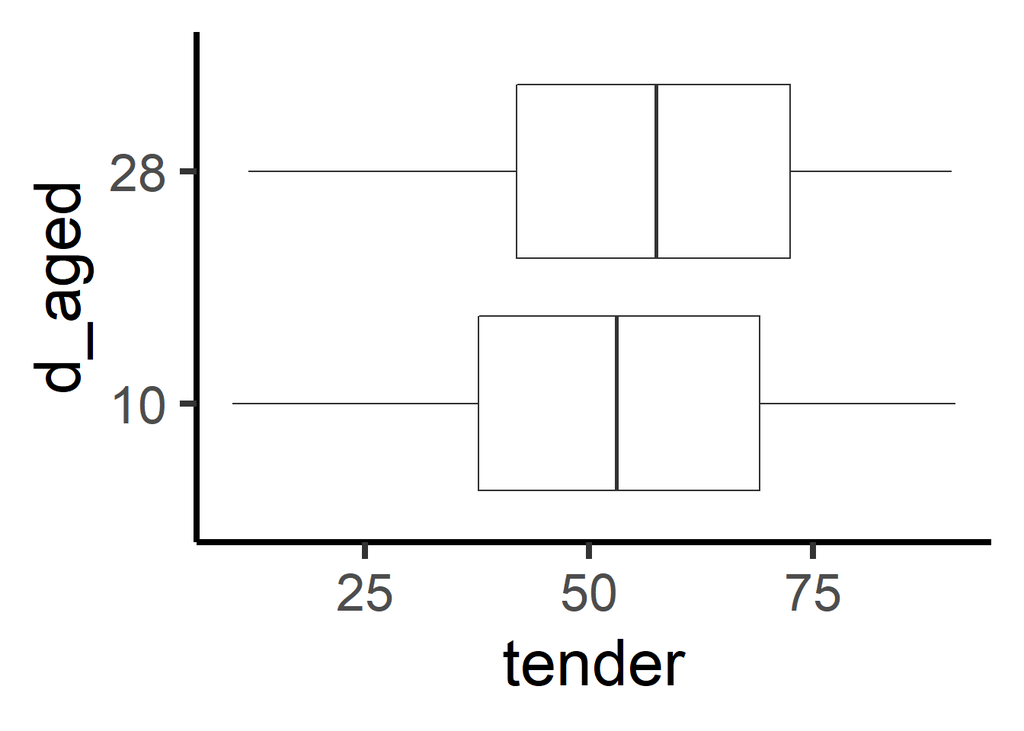

```r
df %>%
  ggplot(aes(x = d_aged, y = tender),
                     fill = (tender)) +
  geom_boxplot() + coord_flip() +
  theme_classic(base_size = 32)
```

Both the sample groups seems have similar distribution and with a close to equal variance and normal distribution.

```r
df %>% group_by(d_aged) %>%
  summarise(mean = mean(tender), median = median(tender),
            min = min(tender), max = max(tender),
            var = var(tender), sd = sd(tender), n = n()) %>%knitr::kable(format = "markdown", digits = 3)
```

| d_aged | mean | median | min | max | var | sd | n |
| --- | --- | --- | --- | --- | --- | --- | --- |
| 10 | 52.583 | 53.1 | 10.2 | 90.9 | 375.068 | 19.367 | 575 |
| 28 | 56.757 | 57.5 | 12.0 | 90.5 | 336.984 | 18.357 | 474 |

There seems to exist a difference in the means, where the 28 days aging period has a greater mean of 56.757 than the 10 days aging periods (52.583). We then test whether this is significant. We perform a 2 sample t-test to examine the significant of the differences between the means of the tenderness with different aging periods of 10 and 28 days.

**Hypothesis** $H_{0}:$ $\mu_{28days} = \mu_{10days}$ means for meat’s tenderness score aging 10 days and 28 days period have no difference

$H_{1}:$$\mu_{28days} > \mu_{10days}$, the mean for 28 days aging is greater than the mean of 10 days aging period.

**Assumptions** Assuming that the samples $X_1...,X_m$are iid$N(\mu x,\sigma^2)$,$Y_1...,Y_m$ are iid $N(\mu x,\sigma^2)$ and $X_i's$ are independent of Y’s.

Checking assumptions:

As the aging period of 10 days does not affect the aging period of 28 days the 2 samples are independent of each other. Furthermore, the samples are iid. since the large samples size closing to normal distribution. Thus both the assumptions are satisfied, we continue the test.

```r
t.test(tender ~ d_aged , data = df,alternative =  "greater", var.equal = TRUE )
```

```
##
##  Two Sample t-test
##
## data:  tender by d_aged
## t = -3.5568, df = 1047, p-value = 0.9998
## alternative hypothesis: true difference in means is greater than 0
## 95 percent confidence interval:
##  -6.106371       Inf
## sample estimates:
## mean in group 10 mean in group 28
##         52.58267         56.75692
```

**Test statistic**

$T =$ $\dfrac{\bar X - \bar Y }{S_p \sqrt{1/n_1 +1/n_2} }$ Under $H_0, T$~ $t_1047$

**Observed test statistic**

$t_0 = -3.5568$

**P-value:**

$P(t_0 \geq -3.5568) = 0.9998$

**Decision**

#### 2.4.2.3 Difference of tenderness between muscles?

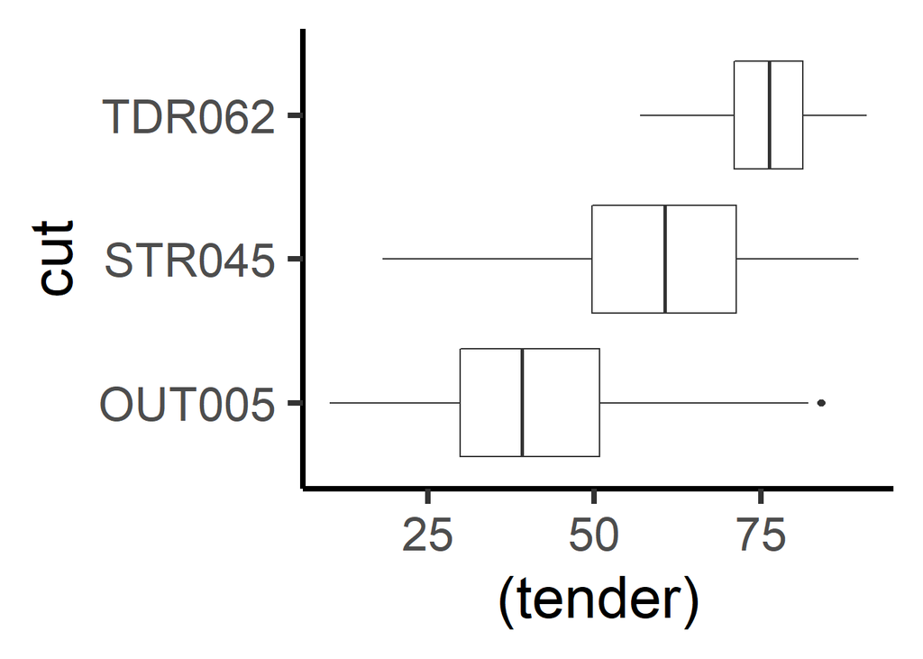

```r
df %>% ggplot(aes(x = cut , y = (tender), fill = tender)) +
  geom_boxplot() + coord_flip() +
  theme_classic(base_size = 32)
```

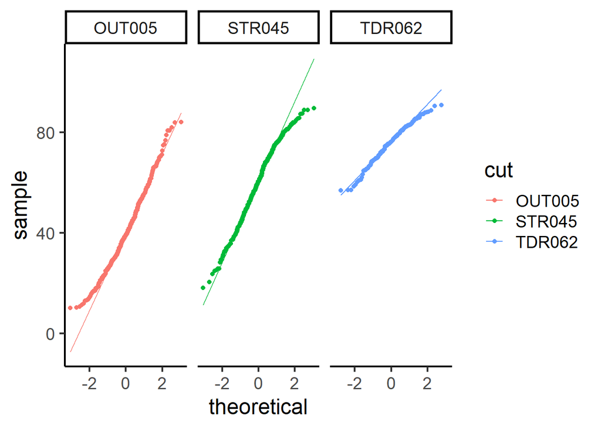

```r
df %>% ggplot(aes(sample = tender, colour = cut)) +
  geom_qq() + geom_qq_line() +
  facet_wrap(~cut) +
  theme_classic(base_size = 18)
```

As shown in the qq-plot are mostly align with the line, hence the normality assumption of the ANOVA test is likely satisfied. However, the equal variance assumption is slightly violated shown in the box plots as the muscle cut for TDR062 (tenderloin) seems to have a smaller variance than the other 2 groups. However, we continue with the test.

This 2-way ANOVA test includes the consideration of the significant interaction effects and effective blocks:

$Y_{ijk}=μ+α_i+(αγ)_{ij}+(αb)_{ik}+d_m+e_n+ε_{ijk}$

$∑_iα_i=0$ $∑_md_l=0$ $∑_ne_l=0$

For each j, $∑_i(αγ)_{ij}=0$ For each i, $∑_i(αγ)_{ij}=0$ For each i, $∑_i(αb)_{ik}=0$ For each k, $∑_i(αb)_{ik}=0$

Let α_1, α_2,α_3 be the treatment effects for the 3 different cuts of muscle (OUT005 for outside flat, STR045 for striploin and TDR062 for tenderloin.)

**Hypothesis:**

$H0: α_1=α_2=α_3=0$

$H1:$ not all $α_i$ equal to 0

**Assumptions:**

ANOVA assumes the residuals follow a normal distribution with constant variance. We have checked this above using a qqplot and box plot as discussed above.

**Test statistic**

The Test statistic = Mean Sq Interaction/Mean Sq Residual

It also follows a F distribution with $a−1$ and $ab(n−1)$ degrees of freedom under $H_0$.

```r
summary(aov(tender ~ cut + kiwi:cut + cook:cut + carcase_no + key_1, data = df))
```

```
##              Df Sum Sq Mean Sq F value   Pr(>F)
## cut           2 180818   90409 773.676  < 2e-16 ***
## carcase_no    1    285     285   2.442    0.118
## key_1        85  22679     267   2.283 2.79e-09 ***
## cut:kiwi      2  51772   25886 221.519  < 2e-16 ***
## cut:cook      9  12759    1418  12.132  < 2e-16 ***
## Residuals   949 110897     117
## ---
## Signif. codes:  0 '***' 0.001 '**' 0.01 '*' 0.05 '.' 0.1 ' ' 1
```

**Observed test statistic:**

The observed test statistic is $t_0 = 773.676$.

**P-value:**

**Conclusion:**

As the p-value, p < 0.00001 is significantly less than 0.05 (with level of significance at 5%), there is evidence against $H_0$ at the 5% level of significance to suggest a statistically significant differences of the tenderness between the different cuts of the muscles.

#### 2.4.2.4 Does tenderness affect overall liking of the meat?

Lastly, to confirm our assumptions, we check if tenderness does have an effect on the overall liking of participants to the meat.

```r
# organising data
q5dat = data
tender = q5dat$Tender
ovl = q5dat$`O/all Like`
```

Visualising our data:

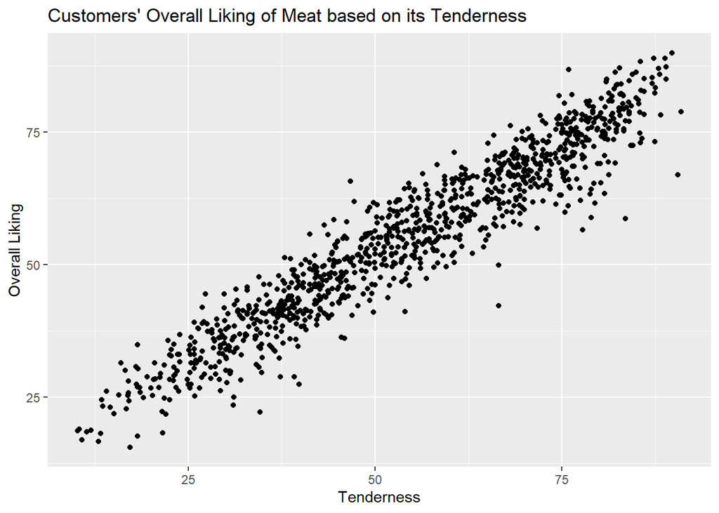

```r
q5dat %>%
  ggplot(aes(x=tender, y=ovl)) +
  geom_point() +
  labs(x = "Tenderness", y = "Overall Liking", title = "Customers' Overall Liking of Meat based on its Tenderness")
```

From the scatter plot generated, it looks like there is likely to be a relationship between tenderness and overall liking of the meat.

Since we are testing for correlation between two continuous variables (tenderness and overall liking), a Pearson’s correlation test is used (Puth et al., 2014).

**Hypothesis:**

$H_0: ρ = 0$

$H_1: ρ ≠ 0$

**Assumptions:**

Linearity and homoskedascity: the data for tenderness and overall liking are linearly related, as evident from the scatter plot above. Similarly, the data distribution is fairly homoskedastic and the plot takes on a tubular shape (rather than conical).

Outliers: the data is visualised below as box-plots, there are no apparent outliers visible.

Normality: from the box-plots constructed below, the data distribution looks approximately normal.

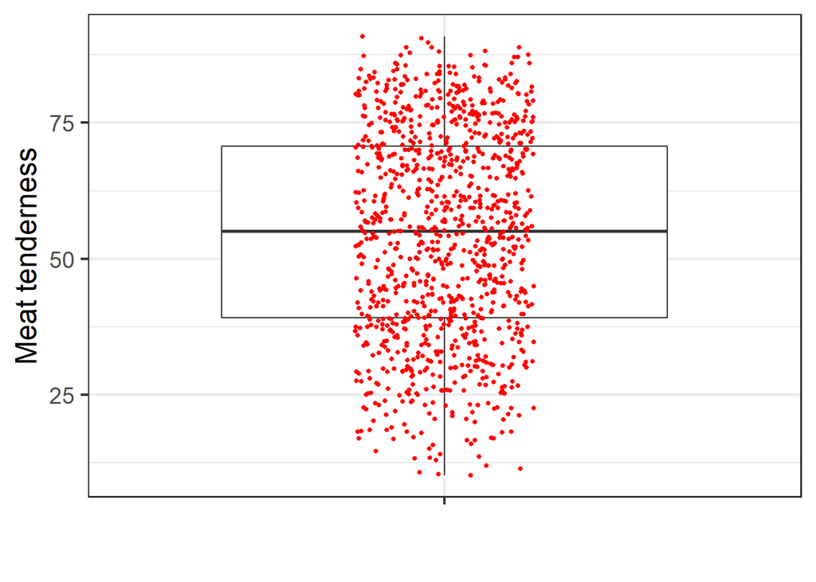

```r
ggplot(q5dat, aes(x = "", y = tender)) +
  geom_boxplot() +
  geom_jitter(width=0.15, size = 1, colour = "red") +
  theme_bw(base_size = 18) +
  labs(x = "", y = "Meat tenderness")
```

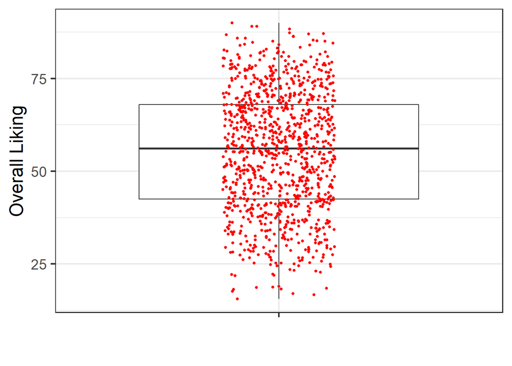

```r
ggplot(q5dat, aes(x = "", y = ovl)) +
  geom_boxplot() +
  geom_jitter(width=0.15, size = 1, colour = "red") +
  theme_bw(base_size = 18) +
  labs(x = "", y = "Overall Liking")
```

**Test statistic:**

```r
cor.test(tender, ovl, method = "pearson", use = "complete.obs")
```

```
##
##  Pearson's product-moment correlation
##
## data:  tender and ovl
## t = 100.35, df = 1047, p-value < 2.2e-16
## alternative hypothesis: true correlation is not equal to 0
## 95 percent confidence interval:
##  0.9456991 0.9571375
## sample estimates:
##       cor
## 0.9517478
```

**P-value:**

Since the p value is less than 0.05, We can conclude that tenderness does have an effect on overall liking. Based on the scatter plot constructed, we can be be confident that this is a positive relationship.

**Conclusion:**

Since the p value is less than 0.05, We can conclude that tenderness does have an effect on overall liking. Based on the scatter plot constructed, we can be be confident that this is a positive relationship.

# 3 Conclusions

In summary, we arrive at the following conclusions:

1. Kiwifruit extract does enhance the tenderness of the meat. p val < 0.00001

This finding comes as no surprise, since previous research has eluded to kiwi fruit extract’s ability to tenderise meat (Toohey et al., 2011)

3. Tenderness has an effect on the customer’s overall liking of the meat.

This confirms the usefulness of kiwifruit extract as a meat tenderiser in improving the customer experience with meat. Furthermore, it is useful to confirm that cooking methods, ageing and choosing different muscle groups will have an effect on the customer’s overall liking and satisfaction of the meat by altering the tenderness of the meat.

## 3.2 Flaws and Future Research

Consumers were untrained and their rating of the meat may not be objective, therefore their ratings are also unstandardised and may vary even for the same meat and experience of the meat. It may be useful in the future to compare ratings of the same meat from untrained consumers and experts.

Grilled meat was heated to approximately 200C but variations in temperature may have affected the cooking of the meat. In the future, the cooking temperature of the meat should be more tightly controlled if possible.

The age of cattle at the time of slaughter was neither recorded nor standardised, although it is known that it affects the tenderness of meat (Xion et al., 2007). Therefore, future experiments should either control for age or record it as an additional factor.

Since actinidin has also been found to improve the tenderness of lamb (Han et al., 2009) and pork (Christensen et al., 2009), further exploration using similar parameter and protocols could prove useful and reveal ways to add value to cheaper cuts of meat from different animals. Additionally, similar experiments may investigate the effects of actinidin on the tenderness of traditionally tougher meats, such as mutton.

## 3.3 Closing Comments

Analysis of experimental results reveal promising uses of the kiwifruit protease actinidin in adding value to cheaper cuts of beef by improving its tenderness. Other methods to alter tenderness include ageing the meat, changing the method of its cooking, and choosing a more tender cut of meat.

These findings have potential to improve the eating experience of consumers, especially those that consume cheaper cuts of meat and are therefore more likely to be from a low socioeconomic background. Since food is such an integral part of daily living and beef is so commonly consumed, actinidin use in beef may improve the quality of life for many with lower incomes.

# 4 References

Christensen, M.; Tørngren, M.A.; Gunvig, A.; Rozlosnik, N.; Lametsch, R.; Karlsson, A.H.; Ertbjerg, P. Injection of marinade with actinidin increases tenderness of porcine M. biceps femoris and affects myofibrils and connective tissue. J. Sci. Food Agric. 2009, 89, 1607–1614.

Han, J.; Morton, J.D.; Bekhit, A.E.D.; Sedcole, J.R. Pre-rigor infusion with kiwifruit juice improves lamb tenderness. Meat Sci. 2009, 82, 324–330.

Puth, M. T., Neuhäuser, M., & Ruxton, G. D. (2014). Effective use of Pearson’s product–moment correlation coefficient. Animal behaviour, 93, 183-189.

Toohey, E. S., Kerr, M. J., Van de Ven, R., & Hopkins, D. L. (2011). The effect of a kiwi fruit based solution on meat traits in beef m. semimembranosus (topside). Meat Science, 88(3), 468-471.

Xiong, Y. L., Mullins, O. E., Stika, J. F., Chen, J., Blanchard, S. P., & Moody, W. G. (2007). Tenderness and oxidative stability of post-mortem muscles from mature cows of various ages. Meat Science, 77(1), 105-113.

Meat Industry Strategic Plan 2020. (n.d.). Retrieved from https://rmac.com.au/wp-content/uploads/2016/12/MISP-2020-doc.pdf

Hadley Wickham (2017). tidyverse: Easily Install and Load the ‘Tidyverse’. R package version 1.2.1. https://CRAN.R-project.org/package=tidyverse

Sam Firke (2019). janitor: Simple Tools for Examining and Cleaning Dirty Data. R package version 1.2.0. https://CRAN.R-project.org/package=janitor

Hadley Wickham and Jennifer Bryan (2019). readxl: Read Excel Files. R package version 1.3.1. https://CRAN.R-project.org/package=readxl

Stefan Milton Bache and Hadley Wickham (2014). magrittr: A Forward-Pipe Operator for R. R package version 1.5. https://CRAN.R-project.org/package=magrittr

Hadley Wickham, Romain François, Lionel Henry and Kirill Müller (2019). dplyr: A Grammar of Data Manipulation. R package version 0.8.3. https://CRAN.R-project.org/package=dplyr

Yihui Xie (2019). knitr: A General-Purpose Package for Dynamic Report Generation in R. R package version 1.24.

Yihui Xie (2015) Dynamic Documents with R and knitr. 2nd edition. Chapman and Hall/CRC. ISBN 978-1498716963

Yihui Xie (2014) knitr: A Comprehensive Tool for Reproducible Research in R. In Victoria Stodden, Friedrich Leisch and Roger D. Peng, editors, Implementing Reproducible Computational Research. Chapman and Hall/CRC. ISBN 978-1466561595

Hao Zhu (2019). kableExtra: Construct Complex Table with ‘kable’ and Pipe Syntax. R package version 1.1.0. https://CRAN.R-project.org/package=kableExtra

Yuan Tang, Masaaki Horikoshi, and Wenxuan Li. “ggfortify: Unified Interface to Visualize Statistical Result of Popular R Packages.” The R Journal 8.2 (2016): 478-489.

Masaaki Horikoshi and Yuan Tang (2016). ggfortify: Data Visualization Tools for Statistical Analysis Results. https://CRAN.R-project.org/package=ggfortify

ANOVA for blocked designs: Use and Misuse - analysis of variance, randomized block, homogeneity of covariances, interaction between factors, Latin squares. (2010). Retrieved October 21, 2019, from Influentialpoints.com website: https://influentialpoints.com/Training/ANOVA_for_blocked_designs_use_and_misuse.html

emmeans package, Version 1.4.1. (2019). Comparisons and contrasts in emmeans. Retrieved October 21, 2019, from R-project.org website: https://cran.r-project.org/web/packages/emmeans/vignettes/comparisons.html

Two-Way ANOVA Test in R - Easy Guides - Wiki - STHDA. (2019). Retrieved October 21, 2019, from Sthda.com website: http://www.sthda.com/english/wiki/two-way-anova-test-in-r#multiple-pairwise-comparison-between-the-means-of-groups

Chapter 16. (n.d.). Retrieved from http://www.biostat.jhsph.edu/~iruczins/teaching/jf/ch16.pdf

Stats: Two-Way ANOVA. (2019). Retrieved October 21, 2019, from Richland.edu website: https://people.richland.edu/james/lecture/m170/ch13-2wy.html

Lees A, Konarska M, Tarr G, Polkinghorne R, McGilchrist P (2019). Influence of kiwifruit extract infusion on consumer sensory outcomes of striploin (M. longissimus lumborum) and outside flat (M. biceps femoris) from beef carcasses. Foods, 8, 332.

Watson R, Polkinghorne R, Thompson JM (2008). Development of the Meat Standards Australia (MSA) prediction model for beef palatability. Australian Journal of Experimental Agriculture 48, 1368-1379.